# index

Diego

01/05/2021

# Avaliação técnica — Data Scientist Jr.

**A atividade consiste em analisar um survey.**

**Para começar, vamos definir e conferir o diretório de trabalho. Este diretório precisa ser da sua máquina.** ** O diretório é de acordo com o caminho no seu computador. **

```r
setwd("C:/FCD/Quaest")
getwd()
```

```
## [1] "C:/FCD/Quaest"
```

**Liberar pacotes para que possam ser utilizados.**

```r
library(gdata)
library(readxl)
```

```r
library(gmodels)
```

```r
library(dplyr)
```

```r
library(ggplot2)
```

**Carregando o dataset.**

```r
df <- read_excel("bd_surveyquaest.xlsx", sheet=1, col_names=TRUE)
```

**Verificando o tipo dos dados.**

```r
str(df)
```

```
## tibble[,7] [1,000 x 7] (S3: tbl_df/tbl/data.frame)
##  $ sbjnum  : num [1:1000] 1.36e+08 1.36e+08 1.36e+08 1.36e+08 1.36e+08 ...
##  $ sexo    : chr [1:1000] "Masculino" "Masculino" "Masculino" "Masculino" ...
##  $ idade   : num [1:1000] 57 32 70 50 24 58 32 17 45 24 ...
##  $ rendaf  : chr [1:1000] "De R$ 2.091,00 a R$ 3.135,00 (+ de 2SM até 3 SM)" "De R$ 2.091,00 a R$ 3.135,00 (+ de 2SM até 3 SM)" "De R$ 5.226,00 a R$ 10.450,00 (+ de 5SM até 10 SM)" "De R$ 2.091,00 a R$ 3.135,00 (+ de 2SM até 3 SM)" ...
##  $ esc     : chr [1:1000] "Ensino médio completo" "Ensino médio completo" "Ensino médio completo" "Ensino fundamental incompleto" ...
##  $ aval_gov: chr [1:1000] "Regular positiva" "Boa" "Boa" "Ótima" ...
##  $ voto1   : chr [1:1000] "Candidato 2" "Ninguém/Branco/Nulo" "Candidato 2" "Candidato 2" ...
```

**Lendo as primeiras linhas.**

```r
head(df)
```

```
## # A tibble: 6 x 7
##    sbjnum sexo    idade rendaf                esc           aval_gov   voto1
##     <dbl> <chr>   <dbl> <chr>                 <chr>         <chr>      <chr>
## 1  1.36e8 Mascul~    57 De R$ 2.091,00 a R$ ~ Ensino médio~ Regular p~ Candidat~
## 2  1.36e8 Mascul~    32 De R$ 2.091,00 a R$ ~ Ensino médio~ Boa        Ninguém/~
## 3  1.36e8 Mascul~    70 De R$ 5.226,00 a R$ ~ Ensino médio~ Boa        Candidat~
## 4  1.36e8 Mascul~    50 De R$ 2.091,00 a R$ ~ Ensino funda~ Ótima      Candidat~
## 5  1.36e8 Mascul~    24 De R$ 3.136,00 a R$ ~ Ensino super~ Boa        Candidat~
## 6  1.36e8 Mascul~    58 De R$ 1.046,00 a R$ ~ Ensino funda~ Regular p~ Ninguém/~
```

**Calculando a quantidade dos respondente do sexo masculino e feminino.**

**Termos mais respondente do sexo feminino.**

```r
table(df$sexo)
```

```
##
##  Feminino Masculino
##       545       455
```

**Calculando a quantidade de voto que o candidatos receberam e ordenando do maior para o menor.**

**Podemos ver que o Canditato 2 obteve mais votos.**

```r
frequencia <- sort(table(df$voto1), decreasing = TRUE)
frequencia
```

```
##
##         Candidato 2 Ninguém/Branco/Nulo               NS/NR         Candidato 1
##                 523                 142                 140                  42
##         Candidato 8         Candidato 5        Candidato 10         Candidato 9
##                  26                  25                  20                  19
##         Candidato 3         Candidato 4         Candidato 6         Candidato 7
##                  16                  12                  10                   7
##        Candidato 12        Candidato 14        Candidato 11        Candidato 13
##                   6                   6                   3                   3
```

**Criando a tabela de contingência com candidato e sexo.**

**Na maioria dos casos, não tivermos muita diferença entre os votos dos homens e mulheres.**

```r
CrossTable(df$voto1, df$sexo,
           prop.r=TRUE, prop.c=FALSE, prop.t=FALSE, prop.chisq=FALSE,
           digits=2)
```

```
##
##
##    Cell Contents
## |-------------------------|
## |                       N |
## |           N / Row Total |
## |-------------------------|
##
##
## Total Observations in Table:  1000
##
##
##                     | df$sexo
##            df$voto1 |  Feminino | Masculino | Row Total |
## --------------------|-----------|-----------|-----------|
##         Candidato 1 |        11 |        31 |        42 |
##                     |      0.26 |      0.74 |      0.04 |
## --------------------|-----------|-----------|-----------|
##        Candidato 10 |        14 |         6 |        20 |
##                     |      0.70 |      0.30 |      0.02 |
## --------------------|-----------|-----------|-----------|
##        Candidato 11 |         1 |         2 |         3 |
##                     |      0.33 |      0.67 |      0.00 |
## --------------------|-----------|-----------|-----------|
##        Candidato 12 |         3 |         3 |         6 |
##                     |      0.50 |      0.50 |      0.01 |
## --------------------|-----------|-----------|-----------|
##        Candidato 13 |         2 |         1 |         3 |
##                     |      0.67 |      0.33 |      0.00 |
## --------------------|-----------|-----------|-----------|
##        Candidato 14 |         6 |         0 |         6 |
##                     |      1.00 |      0.00 |      0.01 |
## --------------------|-----------|-----------|-----------|
##         Candidato 2 |       295 |       228 |       523 |
##                     |      0.56 |      0.44 |      0.52 |
## --------------------|-----------|-----------|-----------|
##         Candidato 3 |         9 |         7 |        16 |
##                     |      0.56 |      0.44 |      0.02 |
## --------------------|-----------|-----------|-----------|
##         Candidato 4 |         4 |         8 |        12 |
```

[output cut: 12 more lines]

```
##                     |      0.54 |      0.46 |      0.03 |
## --------------------|-----------|-----------|-----------|
##         Candidato 9 |         7 |        12 |        19 |
##                     |      0.37 |      0.63 |      0.02 |
## --------------------|-----------|-----------|-----------|
## Ninguém/Branco/Nulo |        72 |        70 |       142 |
##                     |      0.51 |      0.49 |      0.14 |
## --------------------|-----------|-----------|-----------|
##               NS/NR |        83 |        57 |       140 |
##                     |      0.59 |      0.41 |      0.14 |
## --------------------|-----------|-----------|-----------|
##        Column Total |       545 |       455 |      1000 |
## --------------------|-----------|-----------|-----------|
##
##
```

**Criando gráfico da quantidade de votos que o candidtato obteve.**

**Aqui podemos ver uma enorme diferença de votos do Candidato 2 aos demais candidatos.**

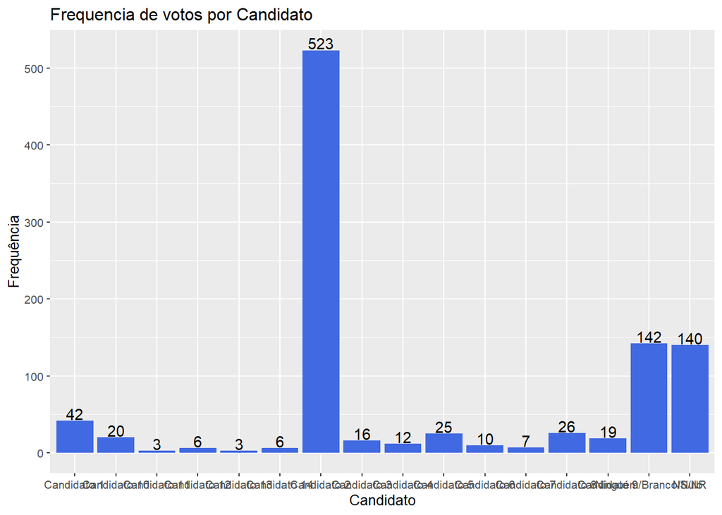

```r
df %>%
  group_by(voto1) %>%
  summarise(n = n()) %>%
  ggplot(aes(voto1, n, label = n)) +
  geom_col() +
  geom_bar(stat = "identity", fill = "RoyalBlue") +
  geom_text(aes(y = n), vjust = -0.1) +
  labs(title = "Frequencia de votos por Candidato", x = "Candidato", y = "Frequência") +
  theme_grey(base_size = 10)
```

**Verificando a quantidade de avaliação do governo.**

**Tivemos mais quantidade de avaliação Boa.**

```r
table(df$aval_gov)
```

```
##
##              Boa            NS/NR            Ótima          Péssima
##              443               14              181               64
## Regular negativa Regular positiva             Ruim
##               74              175               49
```

**Criando tabela cruzada entre candidato e avaliação do governo.**

**Tendo novamente boa avaliação para o candidato 2**

```r
table(df$voto1, df$aval_gov)
```

```
##
##                       Boa NS/NR Ótima Péssima Regular negativa Regular positiva
##   Candidato 1          14     0     3       5                7               10
##   Candidato 10          6     0     2       2                1                8
##   Candidato 11          0     0     1       1                0                0
##   Candidato 12          2     0     2       1                0                1
##   Candidato 13          1     0     1       0                1                0
##   Candidato 14          2     0     1       1                1                1
##   Candidato 2         300     1   154       1                7               59
##   Candidato 3           8     0     0       0                4                2
##   Candidato 4           6     0     0       0                2                4
##   Candidato 5          11     0     0       1                7                4
##   Candidato 6           4     0     0       1                3                2
##   Candidato 7           1     0     0       1                2                2
##   Candidato 8           2     0     3       7                5                5
##   Candidato 9           7     0     1       1                1                6
##   Ninguém/Branco/Nulo  36     5     8      25               20               35
##   NS/NR                43     8     5      17               13               36
##
##                       Ruim
##   Candidato 1            3
##   Candidato 10           1
##   Candidato 11           1
##   Candidato 12           0
##   Candidato 13           0
##   Candidato 14           0
##   Candidato 2            1
##   Candidato 3            2
##   Candidato 4            0
##   Candidato 5            2
##   Candidato 6            0
##   Candidato 7            1
##   Candidato 8            4
##   Candidato 9            3
##   Ninguém/Branco/Nulo   13
##   NS/NR                 18
```

**Verificando a quantidade de avaliação Ótima por candidato.**

```r
ava_otima <- filter(df, aval_gov == "Ótima")
df_otima <- data.frame(table(ava_otima$voto1, ava_otima$aval_gov))
df_otima$Var2 = NULL
colnames(df_otima)[1]<-'Candidato'
colnames(df_otima)[2]<-'Qtd_Otima'

df_otima %>%
  arrange(desc(Qtd_Otima))
```

```
##              Candidato Qtd_Otima
## 1          Candidato 2       154
## 2  Ninguém/Branco/Nulo         8
## 3                NS/NR         5
## 4          Candidato 1         3
## 5          Candidato 8         3
## 6         Candidato 10         2
## 7         Candidato 12         2
## 8         Candidato 11         1
## 9         Candidato 13         1
## 10        Candidato 14         1
## 11         Candidato 9         1
```

**Verificando a quantidade de avaliação Péssima por candidato.**

**Aqui vermos que quem opinou por Ninguém/Branco/Nulo, se teve maior quantidade em avaliar em péssimo.**

```r
ava_pessima <- filter(df, aval_gov == "Péssima")
df_pessima <- data.frame(table(ava_pessima$voto1, ava_pessima$aval_gov))
df_pessima$Var2 = NULL
colnames(df_pessima)[1]<-'Candidato'
colnames(df_pessima)[2]<-'Qtd_Pessimo'

df_pessima %>%
  arrange(desc(Qtd_Pessimo))
```

```
##              Candidato Qtd_Pessimo
## 1  Ninguém/Branco/Nulo          25
## 2                NS/NR          17
## 3          Candidato 8           7
## 4          Candidato 1           5
## 5         Candidato 10           2
## 6         Candidato 11           1
## 7         Candidato 12           1
## 8         Candidato 14           1
## 9          Candidato 2           1
## 10         Candidato 5           1
## 11         Candidato 6           1
## 12         Candidato 7           1
## 13         Candidato 9           1
```

**Vamos montar um gráfico mostrando relação do voto e avaliação do governo.**

**O candidato 2 teve grande quantidade de avaliação Ótima e Boa.** **Ninguém/Branco/Nulo, NS/NR e Candidato 8, teve mais avaliação negativa.** **Os candidatos de 3 a 7, não teve avaliação de Ótima.**

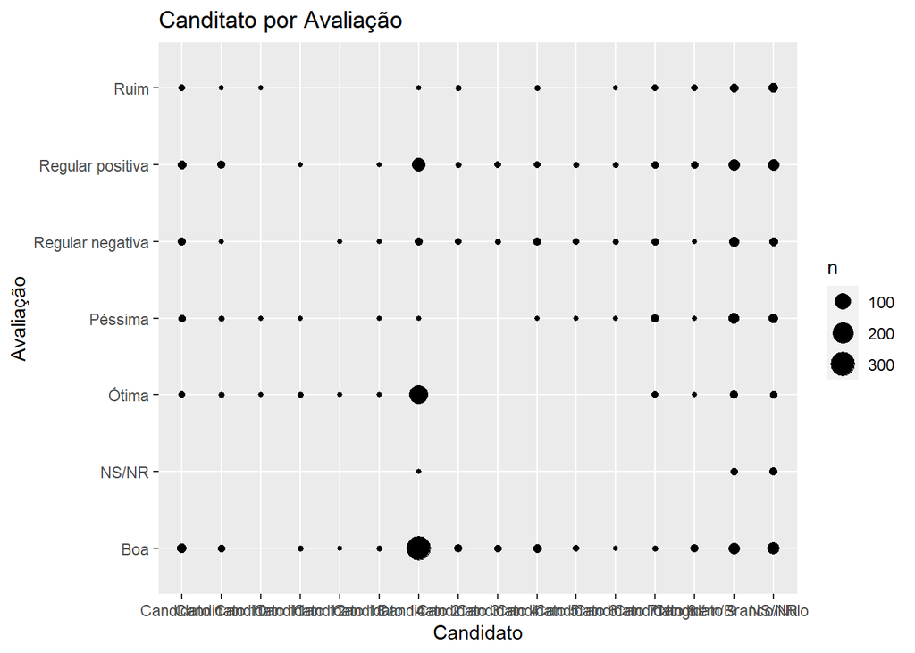

```r
ggplot(df, aes(voto1, aval_gov)) + geom_count() + geom_blank() +
labs(title = "Canditato por Avaliação", x = "Candidato", y = "Avaliação")
```